# Introdução à Ciência de Dados

Fundamentos de Probabilidade para Decisões - Parte 1

Prof. Washington Santos da Silva

IFMG - Campus Formiga

23 de maio de 2025

## Diário de Bordo

**O que vimos até hoje?**

- Aula 1 ✅
  - Introdução e Contextualização ✅
  - O que é Ciência de Dados? ✅
  - Papéis Profissionais na Área de Dados ✅
  - Áreas de Aplicações ✅
  - Habilidades Interpessoais e Analíticas ✅
  - Apresentação da Disciplina ✅
- Aula 2 ✅
  - Metodologia CRISP-DM ✅
  - Tipos de Análise ✅
    - Descritiva ✅
    - Diagnóstica ✅
    - Preditiva ✅
    - Prescritiva ✅
  - Configurações: Git/GitHub ✅
- Aula 3 ✅
  - Introdução ao RStudio ✅
    - Criação do **seu** Projeto RStudio da Disciplina ✅
- Aula 4 ✅
  - Introdução ao Git e GitHub ✅
    - Criação do **seu** repositório do projeto RStudio da disciplina no GitHub ✅
- Aula 5 ✅
  - Breve Revisão do IDE RStudio ✅
  - Introdução ao Sistema de Publicação Quarto ✅
  - Sessão Prática Guiada com Relatório 1 ✅
    - Execução dos comandos git essenciais ✅
- Aula 6 ✅
  - Parte I ✅
    - O Relatório Junglivet e a Metodologia CRISP-DM ✅
    - Primeiro contato com a linguagem R por meio dos códigos do relatório ✅
  - Parte II ✅
    - Para alunos com projetos estruturados ✅
    - Atividade prática ✅
    - Para alunos com dificuldades técnicas ✅
    - Atendimento individualizado para estruturação de projetos ✅
- Aula 7 ✅
  - Introdução ao sistema Quarto (continuação) ✅
    - Gerar relatório no formato pdf ✅
    - Gerar relatório no formato docx ✅
  - Introdução à Linguagem R (continuação) ✅
    - Conceitos: Variáveis e observações ✅
    - Estrutura tabular organizada de dados ✅
    - Tipos e classes de dados principais em R ✅
    - Estruturas de dados: vetores e data frames ✅
- Aula 8 ✅
  - Início do estudo do pacote dplyr para manipulação de dados ✅
    - CRISP-DM: Fase 2 (Entendimento dos dados) e Fase 3 (Preparação dos dados) ✅  
      de um projeto de análise ou ciência de dados ✅
    - O que é o dplyr? ✅
    - A Filosofia *Tidy Data* (Dados Organizados) ✅
    - Dados Organizados (*Tidy Data*) ✅
    - Por que usar o dplyr? ✅
    - Fluxo de trabalho com dplyr ✅
    - Boas Práticas com dplyr ✅
    - Função dplyr::select() ✅
    - Função dplyr::filter() ✅
- Aula 9 ✅
  - Solução dos exercícios práticos sobre as funções select e filter ✅
  - Função dplyr::mutate() ✅
- Aula 10 ✅
  - Soluções dos exercícios práticos sobre a função mutate ✅
  - funções dplyr::group_by(), dplyr::summarize() e dplyr::arrange() ✅
- Aula 11 ✅
  - Metodologia CRISP-DM e Pacote dplyr ✅
  - Revisão sobre Dados Organizados (*Tidy Data*) ✅
  - Exemplos de Dados Desorganizados Comuns em Administração ✅
  - Pacote tidyr: Função pivot_longer ✅
- Aula 12 ✅
  - Metodologia CRISP-DM e o tidyverse ✅
  - Dados Organizados: Potencializando Análises ✅
- Aula 13 ✅
  - Avaliação 1 ✅
- Aula 14 ✅
  - Tipos Básicos de *joins* do pacote dplyr ✅
- Aula 15 ✅
  - Variáveis Aleatórias em Finanças
  - Distribuições de Probabilidade
  - Início: Distribuição Normal (ou Gaussiana)

## Nesta Aula

**Tópicos**

- Fundamentos de Probabilidade para Decisões - Parte 1
  - Distribuição Normal (ou Gaussiana)
  - Características da Distribuição de uma VA
    - Valor Esperado (Média)

## Arquivo para esta Aula (16)

**Instruções**

- Abra o RStudio e o seu Projeto da Disciplina
- Crie a subpasta **09-relatorio** dentro da pasta **relatorios**.
- Acesse o site da disciplina e baixe o arquivo **09-relatorio.zip**
- Descompacte o arquivo, copie/recorte o arquivo `09-relatorio.qmd` e cole dentro da subpasta 09-relatorio.

**Diretrizes para Aulas Mais Produtivas**

🔊 **Mantenha conversas em volume baixo**

⌨️ **Código com método:**

95% dos erros são evitáveis com:

- Atenção na digitação
- Respeitar a sequência lógica de etapas
- Revisão antes de pedir ajuda

🤝 **Inteligência colaborativa:**

- Compartilhe conhecimento
- Resolva questões técnicas simples com colegas próximos
- Reserve ao professor as dúvidas conceituais complexas

💪 **Capacidade de Resolver Problemas**

Cada erro resolvido é uma evolução da sua habilidade analítica

# Incerteza e Probabilidade

# Distribuição Normal

## Função de Densidade de Probabilidade

**A Distribuição Normal**

**Definição**: Uma variável aleatória (VA) $X$ que segue uma distribuição normal tem sua função de densidade de probabilidade dada por:

$$f(x) = \frac{1}{\sigma \sqrt{2\pi}} e^{-\frac{(x-\mu)^2}{2\sigma^2}}$$

**Características principais:**

- A função é **simétrica** em torno da média $\mu$
- O valor máximo ocorre em $x = \mu$
- A área total sob a curva é igual a 1 (100% de probabilidade)

**Parâmetros (Momentos):**

- **Valor Esperado (Média)**: $E[X] = \mu$
- **Variância**: $V[X] = \sigma^2$
- **Desvio-padrão**: $\sigma$

**Notação**: $X \sim N(\mu, \sigma^2)$

## Função de Densidade Normal

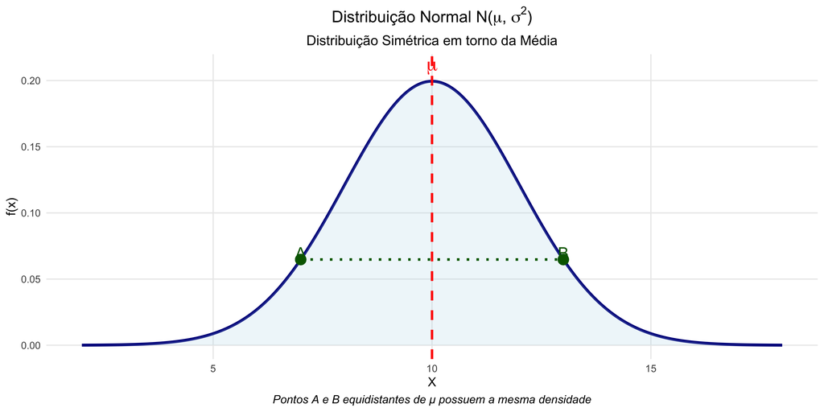

## Distribuição Normal Padronizada

**Padronização: Simplificando os Cálculos**

**Transformação**: Para qualquer $X \sim N(\mu, \sigma^2)$, podemos criar:

$$Z = \frac{X - \mu}{\sigma} \sim N(0, 1)$$

**Função de densidade da Normal Padronizada:**
$$\phi(z) = \frac{1}{\sqrt{2\pi}} e^{-\frac{1}{2}z^2}$$

**Parâmetros:**

- **Média**: $E[Z] = 0$
- **Variância**: $V[Z] = 1$
- **Desvio-padrão**: $\sigma = 1$

**Por que padronizar?**

- Facilita cálculos e comparações
- Permite usar tabelas estatísticas padrão
- Base para o conceito de z-score

## Distribuição Normal Padronizada

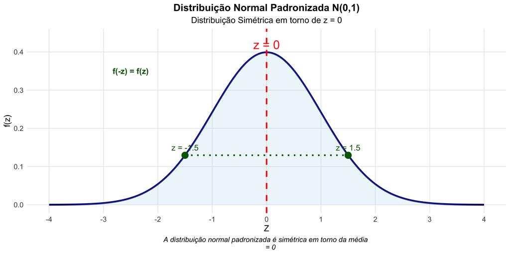

## Distribuição Normal: Efeito da Média

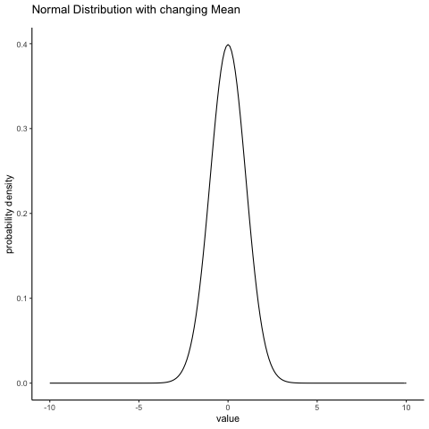

Efeito de Alterar $E[X] = \mu$ (média)

**Observação**

Alterar a média desloca a distribuição horizontalmente sem mudar sua forma

## Distribuição Normal: Efeito da Variância

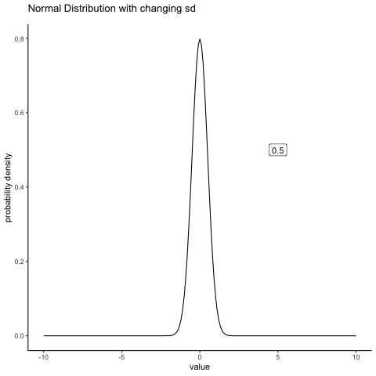

Efeito de alterar $\sigma^2$ (variância)

**Observação**

Maior variância = distribuição mais “dispersa” (maior incerteza)

# Funções R para Distribuição Normal

## A Distribuição Normal em R

**Funções para a Distribuição Normal**

| Função | Resultado |
| --- | --- |
| `rnorm(n, mean=0, sd=1)` | Simula n valores |
| `dnorm(x, mean = 0, sd = 1)` | Densidade f(x) no ponto x |
| `pnorm(q, mean = 0, sd = 1, lower.tail = TRUE)` | $P(X \leq q)$ |
| `qnorm(p, mean = 0, sd = 1, lower.tail = TRUE)` | Quantil: $\Phi^{-1}(p)$ |

## Exemplos:

```r
# Simular 5 valores de uma distr. normal padrão
set.seed(123)
rnorm(5)
```

```
[1] -0.560475647 -0.230177489  1.558708314  0.070508391  0.129287735
```

```r
# f(0) - densidade no ponto 0
dnorm(0)
```

```
[1] 0.39894228
```

```r
# P(Z ≤ 1.96)
pnorm(1.96)
```

```
[1] 0.9750021
```

```r
# Encontra z tal que P(Z ≤ z) = 0.975
qnorm(0.975)
```

```
[1] 1.959964
```

# Função rnorm()

## Simulação de uma VA com Distribuição Normal

**Simulando $X \sim N(\mu = 3, \sigma = 1)$**

**Objetivo**: Verificar empiricamente as propriedades da distribuição normal

**Procedimento**:

1. Gerar 1000 observações de $X \sim N(3, 1)$
2. Calcular média e desvio-padrão amostrais
3. Visualizar com histograma e densidade empírica

```r
set.seed(123)
x_simulada <- rnorm(1000, mean = 3, sd = 1)
head(x_simulada)
```

```
[1] 2.4395244 2.7698225 4.5587083 3.0705084 3.1292877 4.7150650
```

```r
# Média e desvio padrão amostrais
mean(x_simulada)
```

```
[1] 3.0161279
```

```r
sd(x_simulada)
```

```
[1] 0.99169498
```

## Visualização dos Dados Simulados

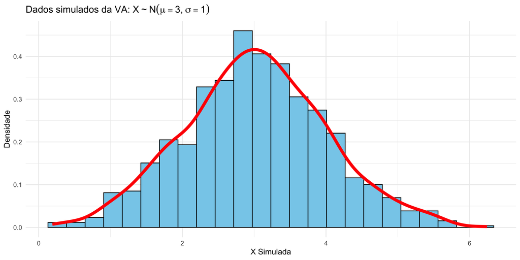

**Lei dos Grandes Números em Ação**

Com 1000 observações, a média amostral (≈3.02) está muito próxima da média teórica (3.0)

## Simulação de uma VA com Distribuição Normal Padronizada

**Simulando $Z \sim N(0, 1)$**

Agora vamos simular a distribuição normal padronizada:

```r
set.seed(123)
z_simulada <- rnorm(1000, mean = 0, sd = 1)
head(z_simulada)
```

```
[1] -0.560475647 -0.230177489  1.558708314  0.070508391  0.129287735
[6]  1.715064987
```

```r
# Média e desvio padrão amostrais
mean(z_simulada)
```

```
[1] 0.016127866
```

```r
sd(z_simulada)
```

```
[1] 0.99169498
```

## Visualização da Normal Padronizada

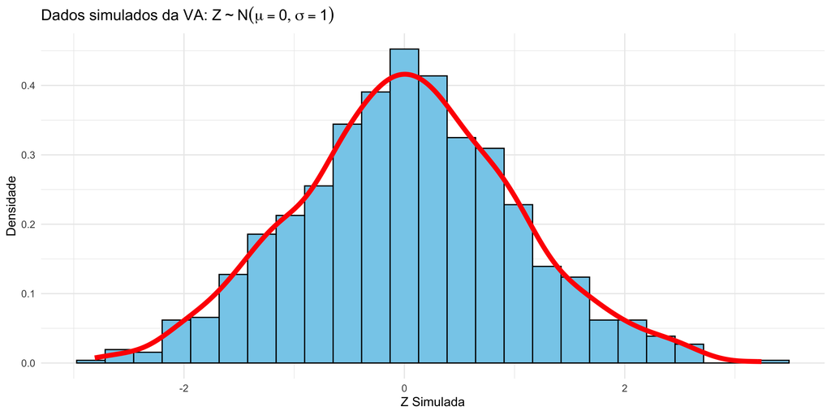

# Função dnorm()

## `dnorm(0)` = $f(0) = 0.4$

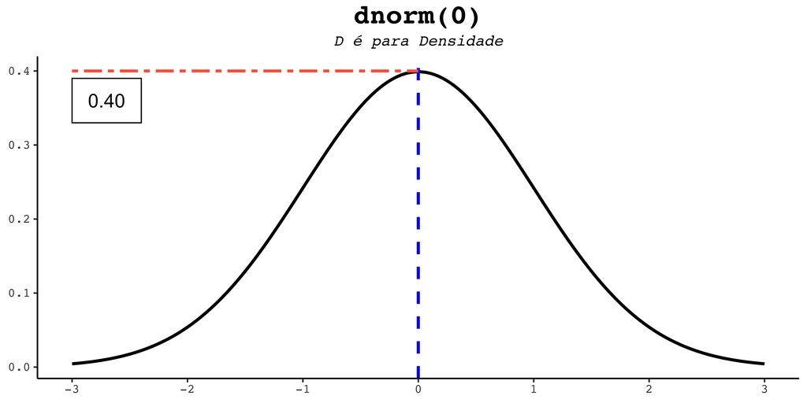

**Interpretação**

dnorm(0) retorna o valor de $f(x)$ no ponto $x = 0$, não uma probabilidade!

# Função pnorm()

## pnorm(0) = $P(Z \leq 0) = 0.5$

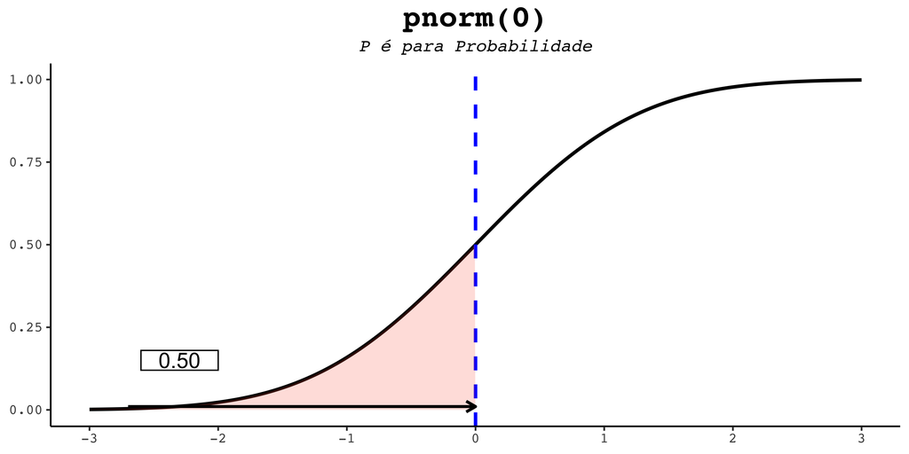

**Interpretação**

pnorm(0) calcula: “Qual a probabilidade de Z ser menor ou igual a 0?”

## pnorm(1) = $P(Z \leq 1) = 0.84$

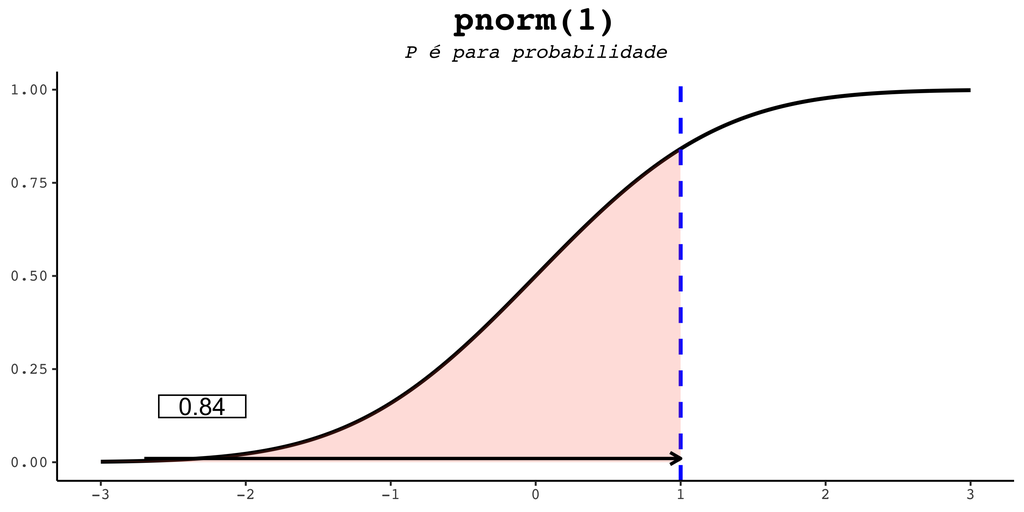

**Interpretação**

pnorm(1) responde: “Qual a probabilidade de Z ser menor ou igual a 1?”

## 1 - pnorm(0) = $P(Z > 0) = 0.5$

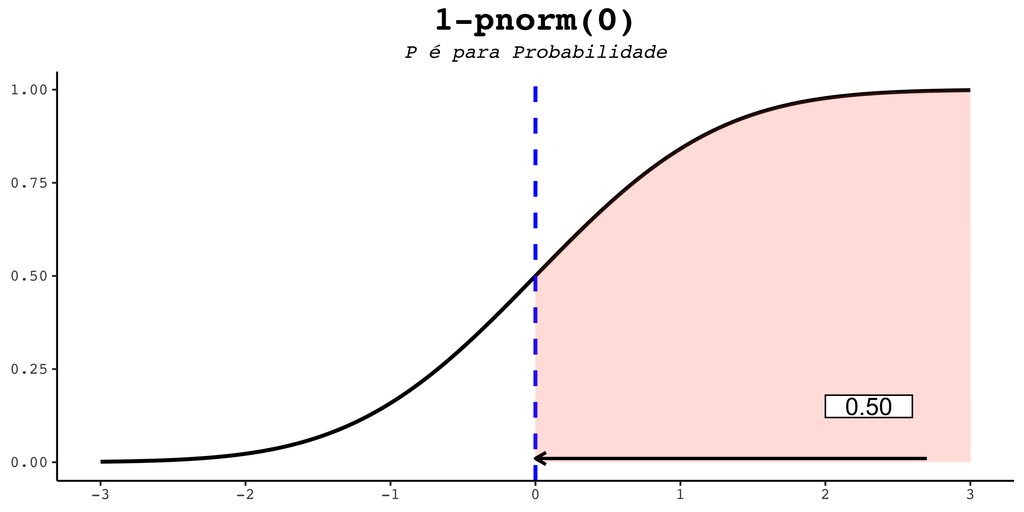

**Interpretação**

1 - pnorm(0) responde: “Qual a probabilidade de Z ser maior que 0?”

## Caso Comum: Probabilidade entre Dois Valores

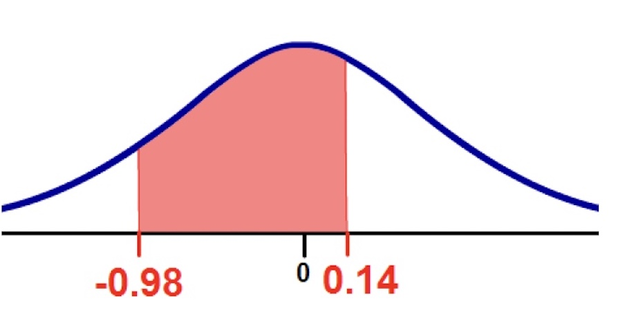

$$\begin{align}
P(-0.98 \leq Z \leq 0.14) &= P(Z \leq 0.14) - P(Z \leq -0.98) \\
&= F(0.14) - F(-0.98) \\
& = \text{pnorm}(0.14) - \text{pnorm}(-0.98) \\
& = 0.5557 - 0.1635 \\
& = 0.3922
\end{align}$$

**Explicação**

A probabilidade de Z estar entre -0.98 e 0.14 é a diferença entre as probabilidades acumuladas até esses pontos.

# Função qnorm()

## qnorm(0.5) = $\Phi^{-1}(0.5) = 0$

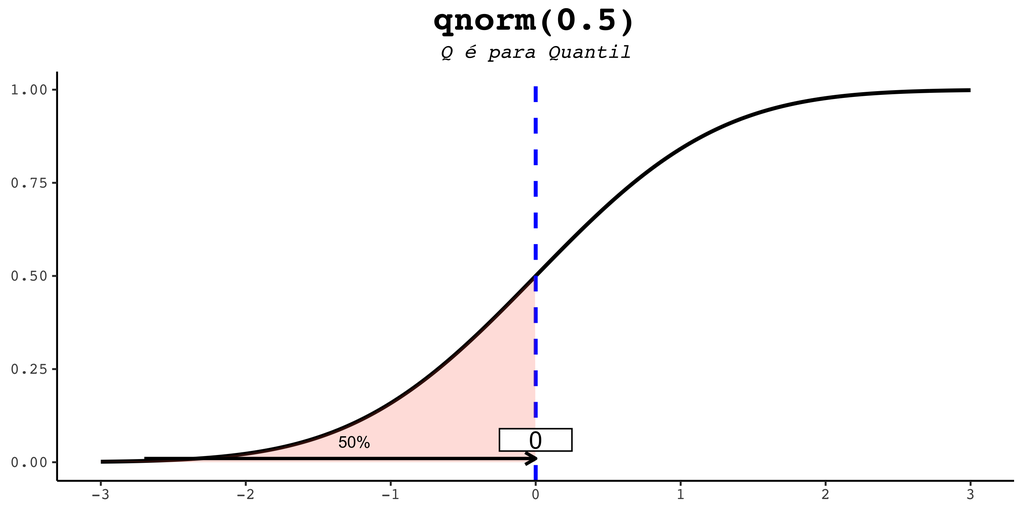

**Interpretação**

qnorm(0.5) calcula: “Qual quantil $Z$ deixa 50% da distribuição à sua esquerda?” Ou seja, $P(Z \leq q) = 0.5$.

## qnorm(0.9) = $\Phi^{-1}(0.9) = 1.28$

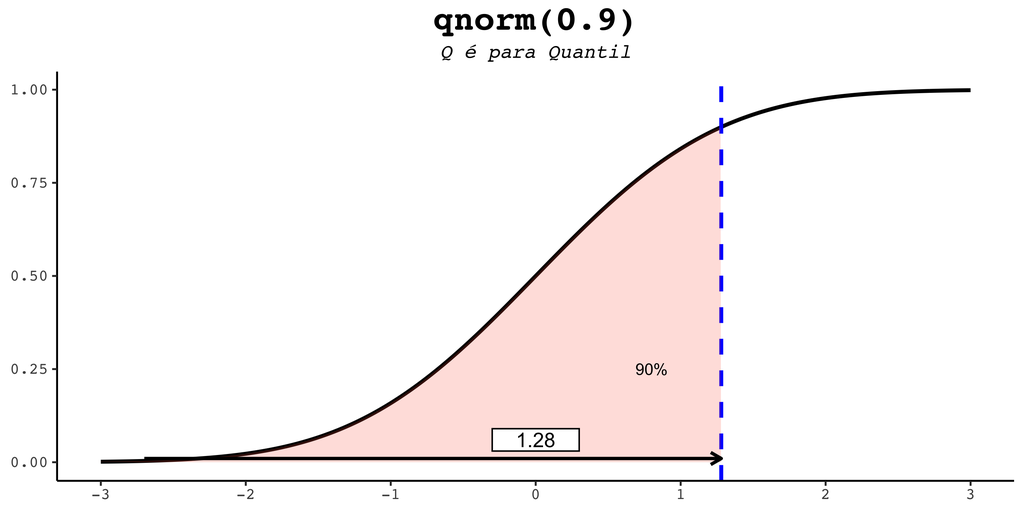

**Interpretação**

qnorm(0.9) calcula: “Qual valor $Z$ deixa 90% da probabilidade à sua esquerda?”

# Score Padronizado (Z-Score)

## Voltando ao Score Padronizado

**Além dos cálculos de probabilidade…**

O **score padronizado (z-score)** tem aplicações importantes no dia a dia profissional:

$$z = \frac{x - \mu}{\sigma}$$

**Por que é útil?**

O z-score nos permite **comparar valores** que estão em escalas completamente diferentes, transformando-os em uma medida comum e interpretável.

**Interpretação:**

- $z = 0$: valor igual à média
- $z = 1$: valor 1 desvio-padrão acima da média
- $z = -2$: valor 2 desvios-padrão abaixo da média

## Aplicação 1: Sistemas de Avaliação

**Comparando desempenho em escalas diferentes**

**Situações comuns:**

- **Concursos públicos**: Como comparar notas de Matemática (0-100) com Redação (0-10)?
- **Avaliação escolar**: Como criar um ranking justo entre diferentes disciplinas?
- **Processos seletivos**: Como ponderar adequadamente critérios diversos?

**Solução**: O z-score padroniza todas as medidas, permitindo comparação direta.

**Exemplo**:

- João: 80 em Matemática (média=70, dp=10) → z = 1.0
- João: 8 em Redação (média=6, dp=1) → z = 2.0
- Conclusão: João teve melhor desempenho relativo em Redação

## Aplicação 2: Ciência de Dados e Machine Learning

**Preparação e análise de dados**

**Principais usos:**

1. **Normalização de variáveis**: Algoritmos como KNN, SVM e redes neurais são sensíveis à escala dos dados. O z-score coloca todas as variáveis na mesma escala.
2. **Detecção de outliers**: Valores com |z| > 2 (ou 3) são considerados atípicos e podem indicar:
   - Erros de digitação
   - Observações genuinamente extremas
   - Insights importantes sobre o processo
3. **Análise exploratória**: Facilita a identificação de padrões e anomalias nos dados.

**Exemplo em R:**

```r
# Detectar outliers usando z-score
dados <- c(10, 12, 13, 11, 14, 45, 12, 11)
z_scores <- scale(dados)
outliers <- abs(z_scores) > 2
dados[outliers]
```

```
[1] 45
```

## Exemplo - Análise de Notas

**Avaliação Relativa da Turma - 19 Alunos**

**Situação**: Após uma avaliação, você deseja fornecer aos alunos uma análise do desempenho relativo de cada um em relação à turma.

**Dados da avaliação:**

- **Média da turma**: 55 pontos (de 100)
- **Desvio padrão**: 12 pontos
- **Amplitude**: notas de 38 a 85 pontos

**Objetivo**: Utilizar o score padronizado para:

1. Mostrar a posição relativa de cada aluno
2. Calcular o percentil de cada aluno
3. Facilitar a interpretação do desempenho individual

## Avaliação Relativa da Turma

**Simula as notas de cada aluno**

```r
# Simulando notas de uma turma de 19 alunos
# Fixa a semente para reprodutibilidade
set.seed(2024)

# Simula notas com média 55 e desvio padrão 12
notas_turma <- round(rnorm(19, mean = 55, sd = 12))

# Limita as notas entre 38 e 85
notas_turma <- pmax(38, pmin(85, notas_turma))

# Visualiza as notas simuladas
head(notas_turma, 19)
```

```
 [1] 67 61 54 52 69 71 61 53 40 42 38 61 65 59 38 53 44 60 38
```

## Avaliação Relativa da Turma

**Cálculo das Notas Relativas**

```r
# Cria a data frame analise_relativa
analise_relativa <- data.frame(alunos = 1:19, notas = notas_turma) %>%
  # Calcula o z-score e nota relativa
  mutate(
    z_score = scale(notas),              # calcula o z-score
    z_score_arred = round(z_score, 1),   # arredonda o z-score
    nota_relativa = round(pnorm(z_score) * 100, 1)  # percentil
  ) %>%
  # Remove coluna intermediária
  select(-z_score)

# Visualiza os dados
head(analise_relativa, 19)
```

```
   alunos notas z_score_arred nota_relativa
1       1    67           1.2          87.9
2       2    61           0.6          73.5
3       3    54           0.0          50.0
4       4    52          -0.2          42.9
5       5    69           1.3          91.1
6       6    71           1.5          93.7
7       7    61           0.6          73.5
8       8    53          -0.1          46.4
9       9    40          -1.3          10.4
10     10    42          -1.1          14.0
11     11    38          -1.4           7.5
12     12    61           0.6          73.5
13     13    65           1.0          83.9
14     14    59           0.4          67.4
15     15    38          -1.4           7.5
16     16    53          -0.1          46.4
17     17    44          -0.9          18.4
18     18    60           0.5          70.5
19     19    38          -1.4           7.5
```

## Interpretação dos Resultados

**Como ler a tabela de análise relativa**

**Colunas da tabela:**

- **notas**: Nota original do aluno (0-100)
- **z_score_arred**: Quantos desvios-padrão acima/abaixo da média
  - Valores negativos: abaixo da média da turma
  - Valores positivos: acima da média da turma
- **nota_relativa**: Percentil do aluno na turma (0-100)
  - Interpretação: “Este aluno superou X% dos colegas”

**Vantagem**: A função `pnorm()` converte automaticamente cada z-score no percentil correspondente

## Exercício: Análise de Investimentos

**Exercício 1**

**Cenário**: A distribuição dos retornos mensais de uma ação segue aproximadamente uma distribuição normal com média de 1% e desvio-padrão de 3% ($R \sim N(\mu = 0.01, \sigma = 0.03)$).

1. Qual a probabilidade de sofrer uma perda mensal superior a 4%? Ou seja, encontre $P(R < -0.04)$.
2. Qual a probabilidade de obter um retorno positivo no próximo mês? Ou seja, encontre $P(R > 0)$.
3. Qual a probabilidade de obter um retorno superior a 5%? Ou seja, encontre $P(R > 0.05)$.

## Exercício: Vendas e Previsão

**Exercício 2**

**Cenário**: As vendas diárias de um produto seguem distribuição normal com média de R$ 12.000 e desvio-padrão de R$ 2.500 ($V \sim N(\mu = 12000, \sigma = 2500)$).

1. Qual a probabilidade de que em um dia as vendas excedam R$ 15.000? Ou seja, encontre $P(V > 15000)$.
2. Para garantir estoque em 95% dos dias, qual deveria ser o valor mínimo de vendas para preparação? Encontre $y$ tal que $P(V < y) = 0.95$.
3. Qual o valor mínimo de vendas esperado com 90% de probabilidade? Encontre $x$ tal que $P(V > x) = 0.90$.

# Valor Esperado

## Características das Distribuições

**Descrevendo Distribuições Matematicamente**

Para entender completamente uma distribuição, precisamos de várias medidas:

**1. Medidas de tendência central**: O “**centro**” da distribuição

- Valor esperado (média) - foco de hoje
- Mediana e quartis

**2. Medidas de dispersão**: A **variabilidade** dos dados

- Variância e desvio-padrão (próxima aula)

**3. Medidas de forma**: O formato da distribuição

- Assimetria (skewness)
- Curtose (kurtosis)

**Aplicação em finanças**: Fundamentais para modelar retornos, precificar ativos e quantificar riscos

## Valor Esperado: Conceito Intuitivo

**A “Média Ponderada pelas Probabilidades”**

**Definição intuitiva**: O valor esperado é o resultado médio que obteríamos se repetíssemos um processo aleatório infinitas vezes

**Analogia física**: É o “centro de massa” da distribuição de probabilidade

**Em termos práticos**:

- Em jogos: o ganho/perda médio por jogada a longo prazo
- Em investimentos: o retorno médio esperado
- Em seguros: o valor médio de sinistros

**Notação**: $E[X]$, $\mu_X$ ou simplesmente $\mu$

**Aplicações principais**:

- Base para tomada de decisão racional
- Precificação justa de ativos e contratos
- Avaliação de projetos e investimentos

## Valor Esperado: Definição Formal

**Definição Matemática**

**Para uma VA Discreta:**
$$E[X] = \mu_X = \sum_{i} x_i \cdot P(X = x_i)$$

**Para uma VA Contínua:**
$$E[X] = \mu_X = \int_{-\infty}^{\infty} x \cdot f(x) \, dx$$

**Exemplo: Lançamento de um dado honesto**

$$\begin{align}
E[X] &= \sum_{i=1}^{6} x_i \cdot P(X = x_i) \\
&= 1 \cdot \frac{1}{6} + 2 \cdot \frac{1}{6} + ... + 6 \cdot \frac{1}{6}\\
&= \frac{1}{6}(1 + 2 + 3 + 4 + 5 + 6) \\
&= \frac{21}{6} = 3.5
\end{align}$$

**Interpretação**: Em média, esperamos obter 3.5 se lançarmos um dado muitas vezes.

## Amostra Aleatória Simples

**Função `sample()` em R**

A função `sample()` executa **amostragem aleatória simples** (AAS), útil em simulações e auditoria.

**Exemplo: Auditoria de Faturas**

Uma empresa emitiu 10.000 faturas. O auditor calculou que uma amostra de 20 é suficiente:

```r
# Fixa a semente do gerador de números aleatórios
set.seed(123)

# Listagem da população de faturas
listagem_populacao <- 1:10000

# Extrai uma AAS com n = 20 da população, sem reposição
faturas_selecionadas <- sample(listagem_populacao, 20)
faturas_selecionadas
```

```
 [1] 2463 2511 8718 2986 1842 9334 3371 4761 6746 9819 2757 5107 9145 9209 2888
[16] 6170 2567 9642 9982 2980
```

**Resultado**: O auditor deve examinar as faturas com os números mostrados acima.

## Valor Esperado: Simulação em R

**Verificação empírica via simulação**

```r
# Definir o número de lançamentos
n_lancamentos <- 10000

# Simular os lançamentos do dado
set.seed(123)  # Para reprodutibilidade
dado <- 1:6
resultados <- sample(dado, n_lancamentos, replace = TRUE)

# Calcular a média empírica após os lançamentos
media_empirica <- mean(resultados)
media_empirica
```

```
[1] 3.4697
```

**Lei dos Grandes Números**: À medida que aumentamos o número de lançamentos (AAS), a média empírica converge para o valor esperado teórico.

## Valor Esperado em Finanças

**Exemplo 1: Análise de Investimento**

Um investimento tem os seguintes retornos possíveis:

| Cenário | Retorno | Probabilidade |
| --- | --- | --- |
| Recessão | -5% | 20% |
| Normal | 10% | 50% |
| Expansão | 25% | 30% |

**Cálculo do retorno esperado:**

$$\begin{aligned}
E[R] &= (-5\%) \times 0.2 + 10\% \times 0.5 + 25\% \times 0.3 \\
&= -1\% + 5\% + 7.5\% \\
&= 11.5\%
\end{aligned}$$

**Interpretação**: O retorno médio esperado deste investimento é 11.5% ao ano.

## Valor Esperado em Finanças

**Exemplo 2: Retorno Esperado de Investimento**

Uma empresa analisa um investimento com os seguintes cenários:

| Cenário | Retorno (R$) | Probabilidade |
| --- | --- | --- |
| Pessimista | -50.000 | 0.2 |
| Moderado | 100.000 | 0.5 |
| Otimista | 300.000 | 0.3 |

**Cálculo do Valor Esperado:**
$$\begin{align}
E[X] &= -50.000 \times 0.2 + 100.000 \times 0.5 + 300.000 \times 0.3 \\
&= -10.000 + 50.000 + 90.000 \\
&= 130.000
\end{align}$$

**Decisão**: Com retorno esperado de R$ 130.000, o projeto parece atrativo.

## Implementação e Simulação

```r
# Definir os dados do investimento
retornos <- c(-50000, 100000, 300000)
probabilidades <- c(0.2, 0.5, 0.3)

# Cálculo teórico do valor esperado
valor_esperado <- sum(retornos * probabilidades)
valor_esperado
```

```
[1] 130000
```

```r
# Simulação para verificação
set.seed(123)
n_simulacoes <- 10000

# Simular investimentos
indices <- sample(1:3, n_simulacoes, prob = probabilidades, replace = TRUE)
retornos_simulados <- retornos[indices]

# Média empírica
media_empirica <- mean(retornos_simulados)
media_empirica
```

```
[1] 130645
```

```r
# Visualiza distribuição dos resultados
table(retornos_simulados) / n_simulacoes
```

```
retornos_simulados
-50000 100000 300000
0.1949 0.5057 0.2994
```

## Explicação da Simulação

**Como funciona a simulação?**

**Objetivo**: Reproduzir virtualmente o investimento milhares de vezes

**Processo passo a passo:**

1. **Preparação**: Definimos retornos possíveis e suas probabilidades
2. **Sorteio de índices**:
   - `sample(1:3, ...)` sorteia posições no vetor de retornos
   - Índice 1 (20% chance) → Retorno de -50.000
   - Índice 2 (50% chance) → Retorno de 100.000
   - Índice 3 (30% chance) → Retorno de 300.000
3. **Acesso aos valores**: `retornos[indices]` converte índices em valores
4. **Lei dos Grandes Números**: Com 10.000 simulações, a média converge para o valor esperado teórico

**Importância**: Permite “experimentar” o investimento virtualmente e observar não apenas a média, mas toda a distribuição de resultados possíveis.

# Aplicações do Valor Esperado

## Aplicação: Mercado de Seguros

**Como as seguradoras precificam apólices?**

**Exemplo: Seguro de Automóvel**

**Dados históricos da seguradora:**

- Probabilidade de sinistro por ano: 2% (0.02)
- Indenização média por sinistro: R$ 20.000

**Passo 1: Calcular o valor esperado de indenizações**

$$E[X] = P(\text{sinistro}) \times \text{Indenização média}$$
$$E[X] = 0.02 \times 20.000 = R\$ 400$$

**Passo 2: Adicionar margem para custos e lucro (20%)**

$$\text{Prêmio} = E[X] \times (1 + \text{margem})$$
$$\text{Prêmio} = 400 \times 1.20 = R\$ 480$$

**Conclusão**: A seguradora deve cobrar R$ 480/ano por apólice

## Lei dos Grandes Números em Seguros

**Por que o modelo de seguros funciona?**

**Lei dos Grandes Números (LGN):**

$$\lim_{n \to \infty} P(|\bar{X}_n - \mu| < \epsilon) = 1$$

**Implicações práticas:**

1. **Previsibilidade com escala**:
   - 100 segurados: alta variabilidade
   - 10.000 segurados: resultados previsíveis
   - 1.000.000 segurados: convergência quase perfeita
2. **Princípio da mutualidade**:
   - O prejuízo de poucos é diluído entre muitos
   - Funciona porque a média converge para o valor esperado
3. **Consequências para o negócio**:
   - Seguradoras pequenas = prêmios maiores (maior incerteza)
   - Necessidade de resseguros para eventos extremos
   - Diversificação geográfica e por tipo de risco

**Limitação**: Eventos catastróficos (pandemias, desastres naturais) violam a independência

## Exemplo Prático: Seguro Residencial

**Exercício Guiado**

**Contexto**: Seguradora oferece proteção contra incêndios residenciais

**Dados históricos:**

- Probabilidade anual de incêndio de uma casa: 1% (0.01)
- Indenização média por incêndio: R$ 150.000
- Margem desejada: 25%

**Perguntas:**

1. Calcule o valor esperado de indenizações por residência
2. Determine o prêmio anual a ser cobrado
3. Implemente a solução em R

## Solução: Seguro Residencial

**Resolução passo a passo**

```r
# Definir os parâmetros
prob_incendio <- 0.01
valor_indenizacao <- 150000
margem <- 0.25

# a) Valor esperado das indenizações
valor_esperado <- prob_incendio * valor_indenizacao
valor_esperado
```

```
[1] 1500
```

```r
# b) Prêmio anual com margem
premio_anual <- valor_esperado * (1 + margem)
premio_anual
```

```
[1] 1875
```

```r
# c) Simulação para verificar
set.seed(123)
n_casas <- 10000
sinistros <- sample(c(0, valor_indenizacao), n_casas,
                   prob = c(0.99, 0.01), replace = TRUE)

# Calcula a média dos sinistros
media_sinistros <- mean(sinistros)
media_sinistros
```

```
[1] 1515
```

```r
# Calcula o número de incêndios
num_incendios <- sum(sinistros > 0)
num_incendios
```

```
[1] 101
```

## Propriedades do Valor Esperado

**Propriedades Matemáticas Fundamentais**

**1. Linearidade**: $E[aX + bY] = aE[X] + bE[Y]$

**Exemplo - Portfólio de Investimentos:**

- 30% em ações (retorno esperado: 12%)
- 70% em renda fixa (retorno esperado: 5%)

$$E[R_{portfolio}] = 0.3 \times 12\% + 0.7 \times 5\% = 7.1\%$$

**2. Valor esperado de constante**: $E[c] = c$

**3. Independência**: Se X e Y independentes, $E[XY] = E[X] \cdot E[Y]$

**4. Função não-linear**: $E[g(X)] \neq g(E[X])$ em geral

**Aplicação**: Estas propriedades simplificam cálculos complexos em finanças

## Limitações do Valor Esperado

**Por que o valor esperado não é suficiente?**

**Problema: Investimentos com mesmo valor esperado**

**Investimento A:**

- 50% chance: ganhar R$ 100
- 50% chance: ganhar R$ 0
- $E[A] = R\$ 50$

**Investimento B:**

- 50% chance: ganhar R$ 200
- 50% chance: perder R$ 100
- $E[B] = R\$ 50$

**Mesma média, riscos diferentes!**

**Outras limitações:**

1. Ignora eventos extremos (caudas)
2. Utilidade marginal decrescente

**Solução**: Precisamos de medidas de dispersão/variabilidade (próxima aula)

## Utilidade Marginal Decrescente

**Limitação do Valor Esperado**

**Problema: O valor esperado ignora como avaliamos ganhos e perdas**

**Princípio da Utilidade Marginal Decrescente:**

- Cada real adicional gera menor satisfação que o anterior
- Perder R$ 100 causa mais “dor” que o “prazer” de ganhar R$ 100
- O impacto psicológico não é linear

**Exemplo prático com os Investimentos A e B:**

- **Investimento A**: Máxima perda = R$ 0 (sem risco real)
- **Investimento B**: Máxima perda = R$ 100 (risco significativo)
- Para alguém com R$ 1.000 de patrimônio, perder R$ 100 é muito mais impactante que para alguém com R$ 100.000

**Consequência:** Investidores racionais podem preferir menor valor esperado se houver menor risco, especialmente quando as perdas potenciais são significativas em relação ao patrimônio total.

**Implicação:** O valor esperado deve ser complementado com análise de risco e consideração da situação financeira individual.

## Exercício Final

**Análise Comparativa de Projetos**

**Situação**: Sua empresa deve escolher entre dois projetos de investimento:

**Projeto A** (Conservador):

- Investimento: R$ 200.000
- Retornos possíveis:
  - Baixo: R$ 220.000 (prob. 0.3)
  - Médio: R$ 280.000 (prob. 0.4)
  - Alto: R$ 320.000 (prob. 0.3)

**Projeto B** (Arriscado):

- Investimento: R$ 200.000
- Retornos possíveis:
  - Baixo: R$ 180.000 (prob. 0.2)
  - Médio: R$ 260.000 (prob. 0.5)
  - Alto: R$ 400.000 (prob. 0.3)

**Tarefas:**

1. Calcule o lucro esperado de cada projeto
2. Qual projeto escolheria baseado apenas no valor esperado?
3. Que informações adicionais seriam úteis para decidir?

## Atualizando os Repositórios

**Instruções**

1. No terminal do RStudio, verifique quais arquivos/pastas foram modificados ou criados com:

```bash
git status
```

2. Você pode adicionar todos os arquivos de uma vez com:

```bash
git add .
```

3. Execute git status novamente para confirmar que todos os arquivos foram adicionados (aparecerão em verde sob “*Changes to be committed*”):

```bash
git status
```

4. Se tudo estiver em verde, faça um commit com uma mensagem descritiva:

```bash
git commit -m "atualizacoes aula 16"
```

5. Se algum arquivo ou pasta ainda aparecer em vermelho após o segundo git status, adicione as pastas/arquivos um por um:

```bash
git add relatorios/04-relatorio/04-relatorio.qmd
```

6. Execute git status novamente e faça o commit quando todos os arquivos estiverem em verde:

```bash
git commit -m "atualizacoes aula 16"
```

7. Envie o repositório local atualizado para o GitHub:

```bash
git push origin main
```